# Corporate Finance

Lecture 9 extras: Following finance day to day

Camilo Saldarriaga

Finance Department, ESCP Business School, 2026/2027

## Why follow finance every day?

- The ideas of this course (risk and return, the CAPM, market efficiency, capital structure) show up in the news **every day**: a firm borrows to buy back shares, a bank fails, a fund beats the market, or does not.
- A few minutes a day with a good source turns the formulas into stories you remember, and teaches you the vocabulary of the people who work in finance.
- Two free sources to start with:
  1. **Unhedged**, a podcast from the *Financial Times*.
  2. **Money Stuff**, a daily newsletter by Matt Levine at *Bloomberg*.

## Unhedged: the FT markets podcast

[figure not shown]

- A markets podcast from the **Financial Times**, every **Tuesday and Thursday**.
- Hosted by **Rob Armstrong** and **Katie Martin**, FT markets journalists. They explain the big ideas behind what is happening in finance right now.
- **Free.** Listen on:
  - [Spotify](https://open.spotify.com/show/42KqGvg4MxWwUPqZ0t98OC)
  - [Apple Podcasts](https://podcasts.apple.com/podcast/id1691284824)
  - [Acast](https://shows.acast.com/unhedged), or any podcast app: search “Unhedged”.

## Money Stuff: Matt Levine’s newsletter

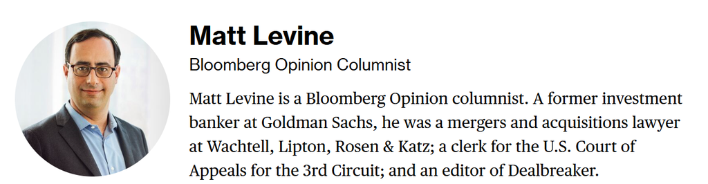

- A column by **Matt Levine** at *Bloomberg Opinion*, sent by email **every weekday**. Deals, scandals and market oddities, explained clearly and with a lot of humour.
- **How to subscribe for free:**
  1. Go to bloomberg.com/account/newsletters/money-stuff.
  2. Create a free Bloomberg account with your email address.
  3. Sign up to *Money Stuff*. The full column arrives in your inbox each weekday, even though most Bloomberg articles on the website are behind a paywall.

## A story to follow: Anthropic’s IPO

- **IPO**: a firm sells its shares to the public for the first time (Chap. 23.2, Lecture 11).
- **26 October 2026**: Anthropic filed its IPO document (S-1) with the SEC. Listing on the **Nasdaq**, ticker **ANT**. Price and size not yet set.
- **Last private value**: $965bn (May 2026), up from $380bn in February.
- **Founders keep 50.1% of the votes**: new shareholders get cash flows, little control.

## Anthropic: the income statement

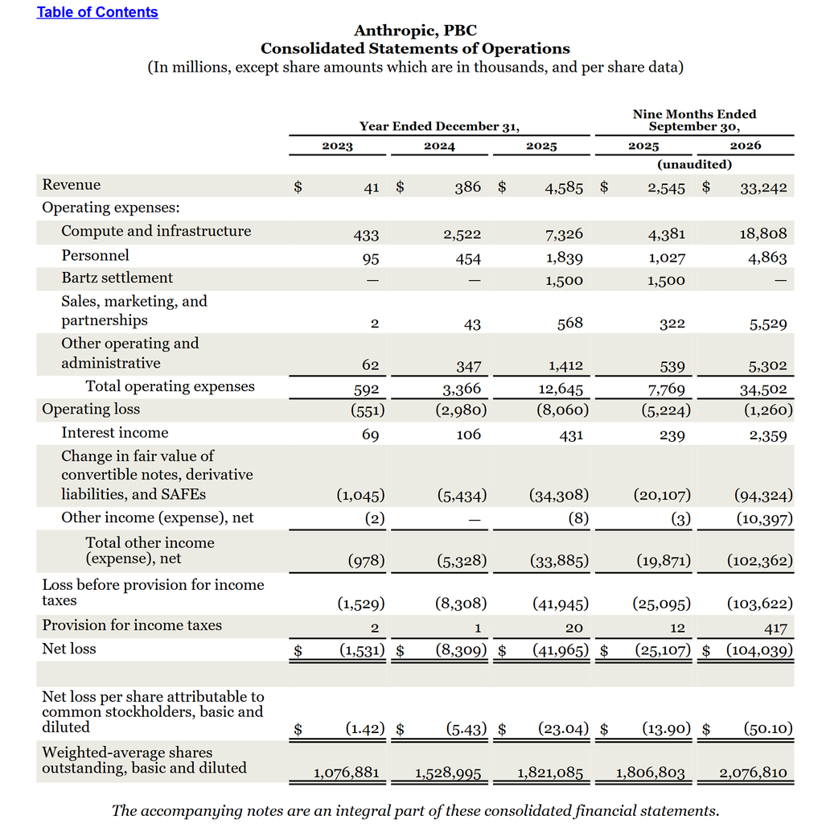

Source: Anthropic, PBC, Form S-1 filed with the SEC, 26 October 2026. Amounts in $ millions.

**[Read the full S-1 filing on sec.gov](https://www.sec.gov/Archives/edgar/data/2130357/000162828026068676/anthropicpbc-sx1ax1.htm#i199fd6a8a0664d5da497db9a78cf0452_241)**

## Anthropic: reading the numbers

- **Revenue explodes**: $4.6bn in 2025, $33.2bn in nine months of 2026.
- **Operating loss shrinks**: $8.1bn in 2025, $1.3bn in nine months of 2026. Biggest cost: **compute**.
- **Why a net loss of $104bn?** $94.3bn comes from **convertible notes** (loans that can turn into shares). As the firm grew more valuable, they became worth more: an accounting loss, with no cash paid out.
- **Course link**: about $417bn promised to compute providers. **Fixed costs** raise risk: operating leverage (Lecture 6).